# INNHotels

Cost Complexity Pruning

```python
# Growing the Full Decision Tree
tree=DecisionTreeClassifier(random_state=42)
tree.fit(X_train,y_train)
```

```
DecisionTreeClassifier(random_state=42)
```

```python
# Compute the cost complexity pruning path
path=tree.cost_complexity_pruning_path(X_train,y_train)

# Extract the alphas (the pruning parameter values) and the corresponding impurities
alphas = path['ccp_alphas']
impurities = path['impurities']
```

```python
pd.DataFrame(path)
```

|  | ccp_alphas | impurities |
| --- | --- | --- |
| 0 | 0.000000e+00 | 0.007615 |
| 1 | -5.421011e-20 | 0.007615 |
| 2 | 2.574018e-07 | 0.007615 |
| 3 | 3.421258e-07 | 0.007615 |
| 4 | 4.375831e-07 | 0.007616 |
| ... | ... | ... |
| 1340 | 7.094216e-03 | 0.286645 |
| 1341 | 1.207180e-02 | 0.298717 |
| 1342 | 1.783521e-02 | 0.316552 |
| 1343 | 2.397477e-02 | 0.364502 |
| 1344 | 7.495203e-02 | 0.439454 |

1345 rows × 2 columns

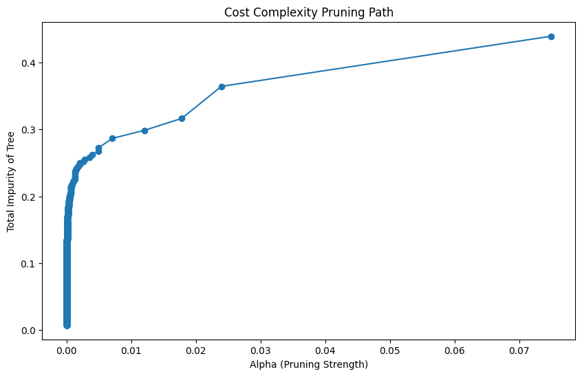

```python
# Plot alpha vs impurity
plt.figure(figsize=(10, 6))
plt.plot(alphas, impurities, marker='o')
plt.xlabel('Alpha (Pruning Strength)')
plt.ylabel('Total Impurity of Tree')
plt.title('Cost Complexity Pruning Path')
plt.show()
```

observation: .At higher alpha value,it will lead to higher impurity, but also a simpler model with better generalization. .At lower alpha values,it will reduce the impurity in the training data, but can cause the tree to overfit and fail to generalize well on new, unseen data.

```python
# Filter out any invalid (negative or zero) alphas
alphas = alphas[alphas >= 0]

# Training decision trees for each value of alpha
trees = []
for alpha in alphas:
    tree_pruned = DecisionTreeClassifier(random_state=42, ccp_alpha=alpha)
    tree_pruned.fit(X_train, y_train)
    trees.append(tree_pruned)
```

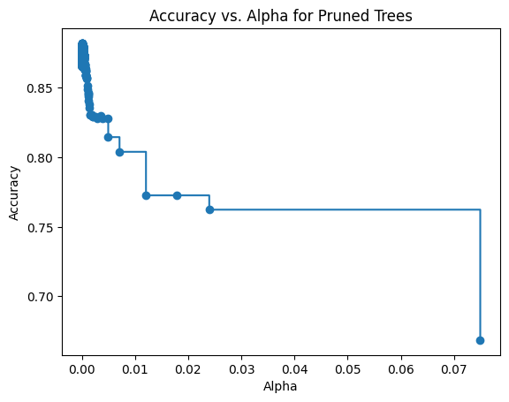

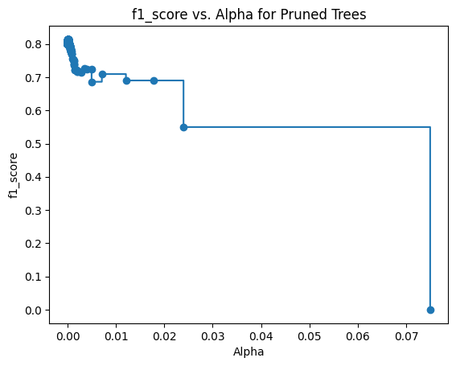

```python
# Evaluate each model's accuracy on the test set
accuracies = [tree.score(X_test, y_test) for tree in trees]

# Plot the accuracy for each alpha value
plt.plot(alphas, accuracies,drawstyle="steps-post",marker='o')
plt.xlabel('Alpha')
plt.ylabel('Accuracy')
plt.title('Accuracy vs. Alpha for Pruned Trees')
plt.show()

# Calculate F1 scores for each pruned tree using tree predictions
f1_scores = [f1_score(y_test, tree.predict(X_test)) for tree in trees]

# Plot the f1_score for each alpha value
plt.plot(alphas, f1_scores,drawstyle="steps-post",marker='o')
plt.xlabel('Alpha')
plt.ylabel('f1_score')
plt.title('f1_score vs. Alpha for Pruned Trees')
plt.show()
```

```python
# Identify the optimal alpha based on maximum accuracy
index_best_model = np.argmax(accuracies)
best_model = trees[index_best_model]
print(best_model)
```

```
DecisionTreeClassifier(ccp_alpha=np.float64(0.00012014020413833593),
                       random_state=42)
```

```
   accuracy    recall  f1_Score  precision
0  0.904497  0.810582  0.846955   0.886745
```

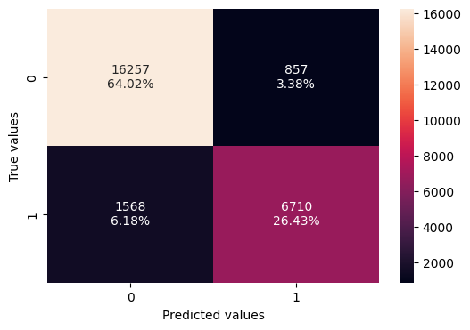

```python
#metrics evaluation on training data
dt_pp_perf_train=metrics_evaluation(best_model,X_train,y_train)
print(dt_pp_perf_train)
#confusion matrix on training data
confusion_mat(best_model,X_train,y_train)
```

```
   accuracy    recall  f1_Score  precision
0   0.88211  0.775991  0.813545   0.854918
```

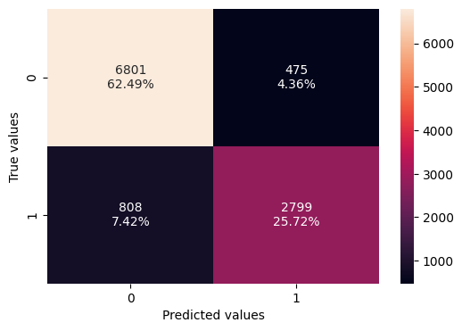

```python
#metrics evaluation on testing data
dt_pp_perf_test=metrics_evaluation(best_model,X_test,y_test)
print(dt_pp_perf_test)
#confusion matrix on testing data
confusion_mat(best_model,X_test,y_test)
```

observations: .The accuracy on training data is 90 , and testing data is 88 . .The f1_score on training data is 85, and testing data is 81 .The small drop in performance metrics (accuracy, recall, F1 score, and precision) from training to testing data suggests that the model might be overfitting. .The model has good overall performance in terms of recall, precision, and F1 score, though there is a slight reduction in these metrics when tested on unseen data.

[figure not shown]

```python
#visualising the Decision tree
from sklearn import tree
feature_names=list(X.columns)
plt.figure(figsize=(20,10))
dt=tree.plot_tree(best_model,feature_names=feature_names,filled=True,fontsize=9,node_ids=False,class_names=True)
plt.show()
```

```python
#checking the significant features
print(pd.DataFrame(best_model.feature_importances_,columns=['Top 5 Significant features'],index=X.columns).sort_values(by='Top 5 Significant features',ascending=False).head(5))
```

```
                            Top 5 Significant features
lead_time                                     0.386744
avg_price_per_room                            0.168811
market_segment_type_Online                    0.140746
no_of_special_requests                        0.103161
arrival_month                                 0.059648
```

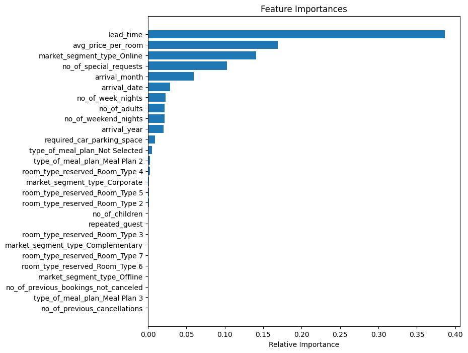

```python
importances = best_model.feature_importances_
indices = np.argsort(importances)

plt.figure(figsize=(8, 8))
plt.title("Feature Importances")
plt.barh(range(len(indices)), importances[indices], align="center")
plt.yticks(range(len(indices)), [feature_names[i] for i in indices])
plt.xlabel("Relative Importance")
plt.show()
```

observations: .Lead time has been the top significant features in all above 3 models.

Comparing model performance

```python
#comparing metrics of training data
perf=pd.concat(
    [dt_perf_train.T,
     dt_tune_perf_train.T,
     dt_pp_perf_train.T],axis=1)
perf.columns=[
    'Decision Tree Sklearn',
    'Decision Tree(pre-pruning)',
    'Decision Tree(post-pruning)']
print("COMPARING METRICS OF TRAINING DATA")
perf
```

```
COMPARING METRICS OF TRAINING DATA
```

|  | Decision Tree Sklearn | Decision Tree(pre-pruning) | Decision Tree(post-pruning) |
| --- | --- | --- | --- |
| accuracy | 0.994290 | 0.823921 | 0.904497 |
| recall | 0.985866 | 0.689780 | 0.810582 |
| f1_Score | 0.991195 | 0.718646 | 0.846955 |
| precision | 0.996581 | 0.750033 | 0.886745 |

```python
#comparing metrics of testing data
perf=pd.concat(
    [dt_perf_test.T,
     dt_tune_perf_test.T,
     dt_pp_perf_test.T],axis=1)
perf.columns=[
    'Decision Tree Sklearn',
    'Decision Tree(pre-pruning)',
    'Decision Tree(post-pruning)']
print("COMPARING METRICS OF TESTING DATA")
perf
```

```
COMPARING METRICS OF TESTING DATA
```

|  | Decision Tree Sklearn | Decision Tree(pre-pruning) | Decision Tree(post-pruning) |
| --- | --- | --- | --- |
| accuracy | 0.865570 | 0.828080 | 0.882110 |
| recall | 0.804269 | 0.683671 | 0.775991 |
| f1_Score | 0.798624 | 0.724974 | 0.813545 |
| precision | 0.793056 | 0.771589 | 0.854918 |

observations: .The accuracy ,f1_score and precision is slightly greater in Decision tree with Post-Pruning model. Thus, post-pruning is a highly effective strategy for this decision tree model, offering a good balance between bias and variance with ccp_alpha value-0.0001201402